# Avoiding Duplicated Nodes in Neo4j with MERGE

When loading data into a Neo4j knowledge graph, CREATE blindly inserts a new node every time, leaving duplicated, disconnected entities. This post explains why MERGE is the safer choice because its match-first-then-create behaviour prevents duplicated nodes.

graph-rag

neo4j

LLM

Author

Mei-Chin Pang

Published

August 9, 2026

# Why `MERGE` is Needed Compared to `CREATE`

In the import queries we wrote earlier, we used `CREATE`, which simply creates a node or relationship exactly as instructed, every time the query runs. That is fine for a single, clean insert, but it becomes a problem the moment the same entity is described more than once. Every track in the CSV has a unique track id, and if a track already exists in the graph we do **not** want to create it again. `CREATE` has no notion of “already there”: it blindly inserts a new node, so the same track ends up stored as several disconnected copies.

We saw exactly this failure in the previous post, Understanding the Fundamentals of Graph RAG. After importing the *tracks* file and the *playlists* file separately with `CREATE`, viewing the whole database showed two chains that should have been joined:

- from the playlists file: `(:User)-[:OWNS]->(:Playlist)-[:HAS_TRACK]->(:Track)`
- from the tracks file: `(:Album)-[:HAS_TRACK]->(:Track)-[:ARTIST]->(:Artist)`

The `Track` in both chains is the *same* song and should be a *single* shared node linking the two subgraphs. Because we used `CREATE`, Neo4j instead produced two separate `Track` nodes. Clicking each one confirmed the problem: their internal `<id>` values differed (they are genuinely distinct nodes), yet their business `id` property was identical, `id: "1FTSo4v6BOZH9QxKc3MbVM"`, which is the `track_id` for that song in both CSV files. That shared `track_id` is the key we can use to recognise the two rows as the same track and collapse them into one node.

## What `MERGE` does differently

`MERGE` is a combination of `MATCH` and `CREATE`. It first tries to find the pattern you are looking for in its entirety, and if it already exists, nothing is created. Only if the pattern cannot be matched is the whole pattern created. This “match first, create only if missing” behaviour is precisely what prevents the duplicate `Track` nodes we saw above.

Because we are looking to avoid duplicate track nodes, `MERGE` needs a reliable **key** to `MATCH` a track on first. The id of the track, album, or artist is unique, so it can be used to determine whether the node already exists in the graph:

```
MERGE (track:Track {id: row.track_id})
SET track.uri = row.track_uri,
    track.name = row.track_name
```

Written this way, loading the playlists file *matches* the existing `Track` node created by the tracks file instead of making a second one, so both patterns attach to a single shared node and the graph becomes properly connected.

## Guarding against parallel duplicates with a constraint

You should also create a uniqueness constraint on the key property. Besides speeding up the `MERGE` match with an index, it guarantees duplicates cannot be created even when data is ingested into the graph in parallel:

```
CREATE CONSTRAINT track_id_unique IF NOT EXISTS
FOR (t:Track) REQUIRE t.id IS UNIQUE;
```

For our current use case, which is the ease of loading data into Neo4j while preventing duplicates, we simply rely on the unique identifiers already available in the dataset (the track, album, and artist ids) as the `MERGE` keys.

# Best Practices for Using `MERGE`

Working with `MERGE` needs some care, and the best advice is to keep it simple. Always remember the core rule: `MERGE` attempts to match the **entire** pattern, and when it cannot, it creates the **entire** pattern. Getting comfortable with this all-or-nothing behaviour is the key to avoiding accidental duplicates.

## A single node is a pattern too

Consider merging one artist node:

```
MERGE (n:Artist {name:"Wham!", origin:"UK"})
```

For this `MERGE` to match an existing node (and therefore not create another one), your graph must already contain:

- a node labeled `Artist` (other labels may exist and do not matter), and
- a property `name` with value `"Wham!"` **and** a property `origin` with value `"UK"` (other properties may exist and do not matter).

If the artist node in your graph has the property `name` with value `"Wham!"` but no `origin` property, the pattern does **not** match, so a new `Artist` node with both properties is created. You now have two `Wham!` artist nodes (assuming a uniqueness constraint did not fail first). The lesson: every property you put inside a `MERGE` becomes part of the key it must match on.

## Patterns with relationships match as a whole

The same all-or-nothing rule applies to patterns that contain relationships. Suppose the artist `Wham!` already exists and you want to link a track to it:

```
MERGE (t:Track {name:"Last Christmas"})-[:ARTIST]->(a:Artist {name:"Wham!"})
```

It is tempting to assume this will reuse the existing `Wham!` node and only create the track and the `ARTIST` relationship. It will not. Because the track `"Last Christmas"` is not yet in the graph, the *entire* pattern fails to match, so `MERGE` creates the entire pattern, including a **second** `Wham!` node.

## Keep it simple: merge nodes first, then relationships

The reliable approach is to `MERGE` each node individually on its key, leaving off the other properties, and then use those matched nodes to `MERGE` the relationship between them:

```
MERGE (t:Track {name:"Last Christmas"})
MERGE (a:Artist {name:"Wham!"})
MERGE (t)-[:ARTIST]->(a)
```

Here each node is matched (or created) on its own key first, so the existing `Wham!` node is reused, and only then is the `ARTIST` relationship merged between the two known nodes. Breaking a compound pattern into separate single-node merges followed by a relationship merge is the safest way to keep your graph free of duplicates.

# Importing One Track with `MERGE`

Applying these practices to our dataset, we rewrite the single-track import to use `MERGE` on each node’s unique id before merging the relationships between them:

```
//Import one track with MERGE
LOAD CSV WITH HEADERS FROM "file:///sample_tracks.csv" AS row
WITH row LIMIT 1

MERGE (track:Track {id: row.track_id})
SET track.uri = row.track_uri,
track.name = row.track_name

MERGE (album:Album {id: row.album_id})
SET album.uri = row.album_uri,
album.name = row.album_name

MERGE (artist:Artist {id: row.artist_id})
SET artist.uri = row.artist_uri,
artist.name = row.artist_name

MERGE (album)-[:HAS_TRACK]->(track)
MERGE (track)-[:ARTIST]->(artist);
```

# Importing One Playlist with `MERGE`

The playlists file follows the same pattern. Each `Playlist`, `User`, and `Track` node is merged on its own id first, and then the `OWNS` and `HAS_TRACK` relationships are merged between the already-matched nodes. Because the `Track` is merged on the same `track_id` used by the tracks import, it reuses the existing node instead of creating a duplicate:

```
//Import one playlist with MERGE
LOAD CSV WITH HEADERS FROM "file:///sample_playlists.csv" AS row
WITH row LIMIT 1

MERGE (playlist:Playlist {id: row.id})
SET playlist.name = row.name

MERGE (user:User {id: row.user_id})
MERGE (track:Track {id: row.track_id})

MERGE (user)-[:OWNS]->(playlist)
MERGE (playlist)-[:HAS_TRACK {position: row.track_index}]->(track);
```

# Check Duplicated Nodes Are Gone

After importing both files with `MERGE`, we can verify that the playlist and the album/artist chains now share a *single* `Track` node instead of two disconnected copies. The following query walks from a user all the way through to the track’s album or artist:

```
MATCH path=(user)-[:OWNS]->(p:Playlist)
-[:HAS_TRACK]->(track:Track)--(albumOrArtist)
RETURN path;
```

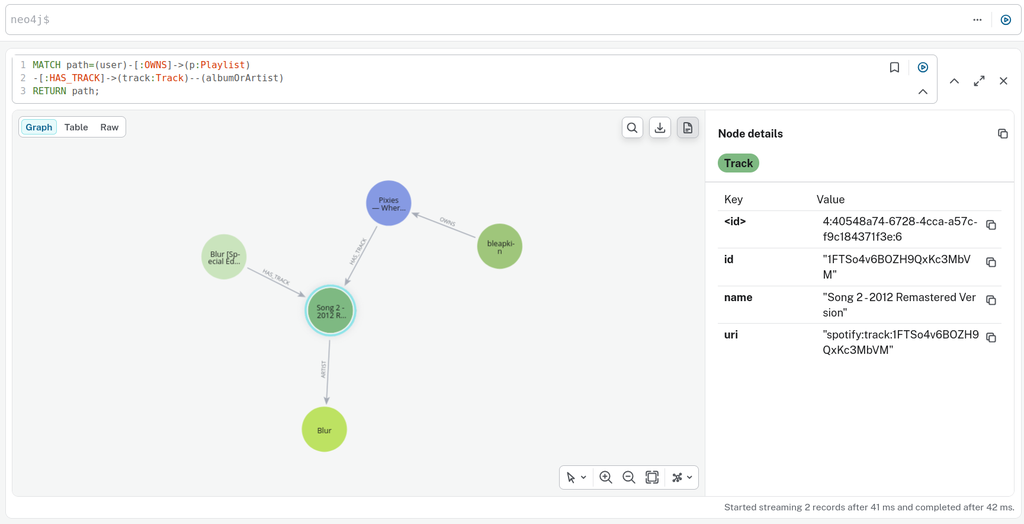

Figure 1: After importing with `MERGE`, the playlist chain and the album/artist chain meet at one shared `Track` node (“Song 2”), whose `id` is `1FTSo4v6BOZH9QxKc3MbVM`.

## Reading the query line by line

- `MATCH path=(user)-[:OWNS]->(p:Playlist)` starts the pattern at a `user` node that `OWNS` a `Playlist`, binding the playlist to `p`.
- `-[:HAS_TRACK]->(track:Track)` follows the playlist’s `HAS_TRACK` relationship to the `Track` it contains, binding it to `track`.
- `--(albumOrArtist)` traverses one more relationship from that track in **any direction and of any type** (the bare `--` has no arrow and no `[:TYPE]`), matching either the `Album` linked by `HAS_TRACK` or the `Artist` linked by `ARTIST`. The neighbouring node is bound to `albumOrArtist`.
- `path=(...)` captures the whole matched chain, and `RETURN path` renders it as a connected subgraph in the Neo4j Browser.

## Why the merged track matters

In Figure 1 the central `Track` node (“Song 2 - 2012 Remastered Version”) is reached from **both** sides at once: the `bleapkin` user’s playlist `Pixies — Wher...` points into it via `HAS_TRACK`, while the album `Blur [Special Edition]` points into it via `HAS_TRACK` and the track points out to the artist `Blur` via `ARTIST`. The node details panel shows its `id`, `1FTSo4v6BOZH9QxKc3MbVM`, exactly the `track_id` shared by both CSV files.

This is the payoff of using `MERGE`: earlier, with `CREATE`, that same `track_id` produced two separate `Track` nodes and left the playlist and album/artist subgraphs disconnected. Because both imports now `MERGE` on `{id: row.track_id}`, the second import *matched* the track created by the first instead of duplicating it, so a single shared node joins the two subgraphs into one connected graph.

# Importing All Playlists with `MERGE`

Once the single-row pattern is verified, we remove the `WITH row LIMIT 1` clause so the same `MERGE` logic runs over every row in the file, importing all playlists at once while still reusing existing `Track` nodes rather than duplicating them. We first import all tracks, merging each `Track`, `Album`, and `Artist` on its unique id and then merging the relationships between them:

```
//merge-all-sample-tracks.cypher
LOAD CSV WITH HEADERS FROM "file:///sample_tracks.csv" AS row
MERGE (track:Track {id: row.track_id})
SET track.uri = row.track_uri,
track.name = row.track_name

MERGE (album:Album {id: row.album_id})
SET album.uri = row.album_uri,
album.name = row.album_name

MERGE (artist:Artist {id: row.artist_id})
SET artist.uri = row.artist_uri,
artist.name = row.artist_name

MERGE (album)-[:HAS_TRACK]->(track)
MERGE (track)-[:ARTIST]->(artist);
```

We then import all playlists, reusing the `Track` nodes created above:

```
//merge-all-sample-playlists.cypher
LOAD CSV WITH HEADERS FROM "file:///sample_playlists.csv" AS row
MERGE (playlist:Playlist {id: row.id})
SET playlist.name = row.name

MERGE (user:User {id: row.user_id})
MERGE (track:Track {id: row.track_id})
MERGE (user)-[:OWNS]->(playlist)

MERGE (playlist)-[:HAS_TRACK {position: row.track_index}]->(track);
```

# Examples of Querying the Graph

**(1) Counting the `Playlist` nodes in the graph**

```
MATCH (n:Playlist)
RETURN count(n) AS playlistCount;
```

Here `MATCH (n:Playlist)` finds every node labeled `Playlist` in the graph and binds each one to `n`, while `count(n)` tallies how many such nodes were matched and `AS playlistCount` names the returned column. As shown in Figure 2, the result is 40, which matches the number of playlists in the source file and confirms they were all imported without duplication.

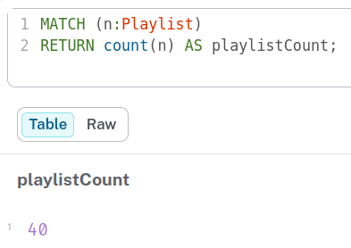

Figure 2: Counting the `Playlist` nodes returns 40, confirming all playlists in the file were imported.

**(2) Finding tracks that appear in more than one playlist**

We can also check whether any track appears in more than one playlist, which is a good sign that `MERGE` reused a single shared `Track` node rather than duplicating it:

```
MATCH (t:Track)<-[:HAS_TRACK]-(p:Playlist)
WITH t AS track, count(p) AS playlistCount
WHERE playlistCount > 1
RETURN track.name as trackName, playlistCount;
```

Reading this query in order: `MATCH (t:Track)<-[:HAS_TRACK]-(p:Playlist)` finds every playlist `p` that contains a track `t`; `WITH t AS track, count(p) AS playlistCount` groups by each track and counts how many playlists reference it; `WHERE playlistCount > 1` keeps only tracks shared by more than one playlist; and `RETURN track.name as trackName, playlistCount` reports those tracks with their playlist counts. As shown in Figure 3, the track “Where Is My Mind?” appears in 2 playlists, confirming that both playlists point to the same single `Track` node.

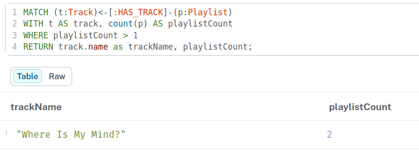

Figure 3: Filtering for tracks shared by more than one playlist returns “Where Is My Mind?” with a `playlistCount` of 2, showing the track node is reused across playlists.

**(3) Finding the artists featured in the most playlists**

We can also rank artists by how many distinct playlists feature their tracks, which shows how the merged graph links artists to playlists through their shared `Track` nodes:

```
MATCH (a:Artist)<-[:ARTIST]-(track)<-[:HAS_TRACK]-(p:Playlist)
RETURN a.name AS artistName, count(distinct p) AS playlistCount
ORDER BY playlistCount DESC
LIMIT 5;
```

Reading this query in order: `MATCH (a:Artist)<-[:ARTIST]-(track)<-[:HAS_TRACK]-(p:Playlist)` finds every playlist `p` that contains a `track` whose artist is `a`; `count(distinct p) AS playlistCount` counts the distinct playlists per artist, so a playlist is only counted once even if it holds several of that artist’s tracks; `RETURN a.name AS artistName, ...` reports each artist with that count; `ORDER BY playlistCount DESC` sorts the busiest artists first; and `LIMIT 5` keeps only the top five. As shown in Figure 4, this returns the five artists whose tracks appear across the most playlists.

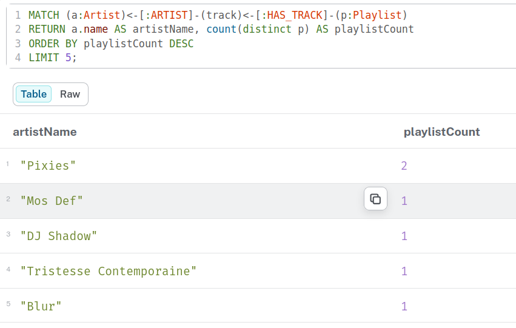

Figure 4: Ranking artists by the number of distinct playlists that feature their tracks returns the top five most-featured artists.

**(4) Inspecting the data type of the `HAS_TRACK` position**

Before relying on the `position` stored on each `HAS_TRACK` relationship, it is worth inspecting a few rows to see how the value was loaded:

```
MATCH (a:Artist)<-[:ARTIST]-(t:Track)<-[r:HAS_TRACK]-(p:Playlist)
RETURN a.name AS artist, t.name as track, r.position as position
LIMIT 5;
```

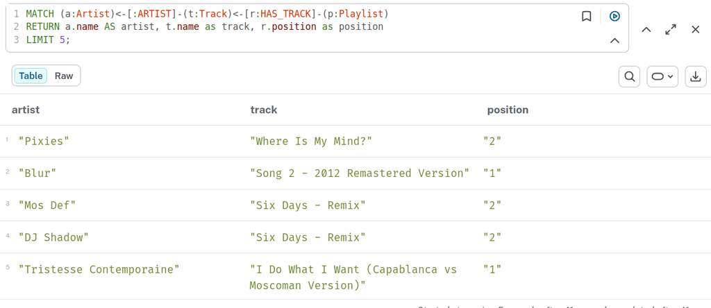

Figure 5: Inspecting the `HAS_TRACK` position shows it is stored as a string, with the values quoted rather than shown as plain numbers.

The reason `position` is a string is that `LOAD CSV` reads every column as text, so `row.track_index` was stored verbatim as a string when the relationships were merged, and Neo4j never coerced it to an integer.

This matters for any query that compares `position` against a number. Take the following query, which tries to find the artist whose track sits in the last position of a playlist by comparing `position` to the playlist’s track count:

```
MATCH (a:Artist)<-[:ARTIST]-(t:Track)<-[r:HAS_TRACK]-(p:Playlist)
WHERE r.position = COUNT { (p)-[:HAS_TRACK]->() }
RETURN a.name AS artist, count(*) AS numberOfTracks
ORDER BY numberOfTracks DESC
LIMIT 1;
```

Here `COUNT { (p)-[:HAS_TRACK]->() }` returns an **integer**, but `r.position` is a **string**, so the comparison `r.position = COUNT { ... }` compares a string to a number. In Cypher those two types are never equal, so the `WHERE` clause filters out every row and the query returns nothing, even though the positions look correct. To make the comparison work, the string must be converted to an integer first, for example with `toInteger(r.position) = COUNT { (p)-[:HAS_TRACK]->() }`.

Rather than converting on every read, we can fix the data at the source by changing the type of the values stored on the `position` property of the `HAS_TRACK` relationships to be an integer:

```
MATCH (p:Playlist)-[r:HAS_TRACK]->()
SET r.position = toInteger(r.position);
```

This matches every `HAS_TRACK` relationship and overwrites its `position` with the integer form of the same value, as shown in Figure 6.

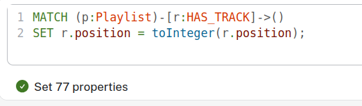

Figure 6: Updating every `HAS_TRACK` relationship so its `position` property is stored as an integer instead of a string.

With `position` now stored as an integer, the original query returns results because the comparison is between two numbers:

```
MATCH (a:Artist)<-[:ARTIST]-(t:Track)<-[r:HAS_TRACK]-(p:Playlist)
WHERE r.position = COUNT { (p)-[:HAS_TRACK]->() }
RETURN a.name AS artist, count(*) AS numberOfTracks
ORDER BY numberOfTracks DESC
LIMIT 1;
```

As shown in Figure 7, the query now matches rows and returns the artist with the most tracks positioned last in a playlist.

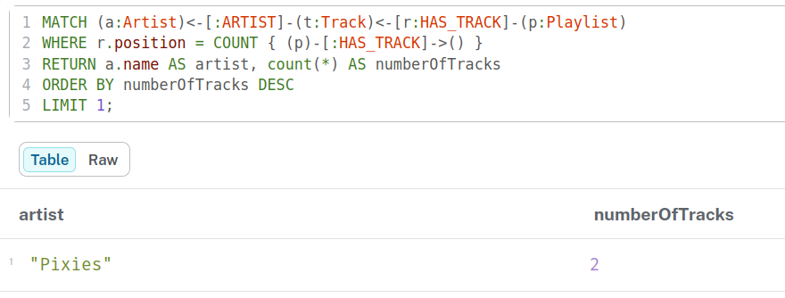

Figure 7: After converting `position` to an integer, the comparison succeeds and the query returns the top artist with a `numberOfTracks` count.

# Viewing the Fully Imported Graph

With every playlist and track imported, we can view the entire database to see the final result. The following query returns all nodes, keeping even those without an outgoing relationship:

```
MATCH (n) OPTIONAL MATCH (n)-[r]->(o) RETURN *
```

[figure not shown]

Figure 8: The complete graph after importing all playlists and tracks with `MERGE`, showing 195 records of connected `User`, `Playlist`, `Track`, `Album`, and `Artist` nodes.

# Adding Constraints in Neo4j Community Edition

With the data imported, a natural next step is to add constraints that keep each node’s `id` unique and present. The `NODE KEY` constraint is the ideal fit because it enforces both at once: the `id` property must **exist** and be **unique**. We might try to create one for every label:

```
//008-index-creation.cypher
// The NODE KEY constraint ensures the id property is present AND unique
CREATE CONSTRAINT playlist_id FOR (n:Playlist) REQUIRE n.id IS NODE KEY;
CREATE CONSTRAINT user_id FOR (n:User) REQUIRE n.id IS NODE KEY;
CREATE CONSTRAINT track_id FOR (n:Track) REQUIRE n.id IS NODE KEY;
CREATE CONSTRAINT album_id FOR (n:Album) REQUIRE n.id IS NODE KEY;
CREATE CONSTRAINT artist_id FOR (n:Artist) REQUIRE n.id IS NODE KEY;
```

On Neo4j Community Edition this fails with:

```
Neo.DatabaseError.Schema.ConstraintCreationFailed
Unable to create Constraint( type='NODE KEY', schema=(:Playlist {id}) ):
Node Key constraint requires Neo4j Enterprise Edition.
```

Both `NODE KEY` and property-existence constraints are **Enterprise-only** features. The only constraint type available in Community Edition is the **uniqueness constraint**, which enforces the *unique* half of a `NODE KEY` but not the *existence* half.

## Using uniqueness constraints instead

We replace each `IS NODE KEY` with `IS UNIQUE`, which Community Edition supports for every label:

```
//008-index-creation.cypher
// Community Edition: uniqueness constraints (unique only, not existence)
CREATE CONSTRAINT playlist_id IF NOT EXISTS
FOR (n:Playlist) REQUIRE n.id IS UNIQUE;
CREATE CONSTRAINT user_id IF NOT EXISTS
FOR (n:User) REQUIRE n.id IS UNIQUE;
CREATE CONSTRAINT track_id IF NOT EXISTS
FOR (n:Track) REQUIRE n.id IS UNIQUE;
CREATE CONSTRAINT album_id IF NOT EXISTS
FOR (n:Album) REQUIRE n.id IS UNIQUE;
CREATE CONSTRAINT artist_id IF NOT EXISTS
FOR (n:Artist) REQUIRE n.id IS UNIQUE;
```

A few things worth noting:

- A uniqueness constraint automatically creates a **backing range index** on `id`, so our `MERGE (n {id: ...})` lookups stay fast without a separate `CREATE INDEX`.
- `IF NOT EXISTS` makes the script safe to run more than once.
- Community Edition cannot enforce the *existence* half, but our imports already set `id` on every `MERGE`, so the key is always present. To double-check, we can look for any node missing the key:

  ```
  MATCH (n:Track) WHERE n.id IS NULL RETURN count(n);
  ```

## Why constraints speed up importing a larger CSV

With the uniqueness constraints in place, we can import a much larger tracks file, `sample_tracks_medium.csv`, using exactly the same `MERGE` logic as before:

```
//import-larger-csv-file-tracks-medium.cypher
LOAD CSV WITH HEADERS FROM "file:///medium/sample_tracks_medium.csv" AS row

MERGE (track:Track {id: row.track_id})
SET track.uri = row.track_uri, track.name = row.track_name

MERGE (album:Album {id: row.album_id})
SET album.uri = row.album_uri, album.name = row.album_name

MERGE (artist:Artist {id: row.artist_id})
SET artist.uri = row.artist_uri, artist.name = row.artist_name

MERGE (album)-[:HAS_TRACK]->(track)
MERGE (track)-[:ARTIST]->(artist);
```

Every `MERGE (track:Track {id: row.track_id})` has to first **match** whether a `Track` with that `id` already exists before deciding to create it. Without an index, Neo4j has no shortcut for that lookup: it must scan **every** existing `Track` node and compare its `id`, which is an $O(n)$ operation. As the graph grows, each successive row scans a larger set of nodes, so the total cost of importing $n$ rows grows roughly as $O(n^2)$. For the tiny sample file this is unnoticeable, but for `sample_tracks_medium.csv`, with many more rows, that quadratic behaviour quickly makes the import slow.

Creating the uniqueness constraint first fixes this. As noted above, a uniqueness constraint automatically builds a **backing range index** on the `id` property. With that index, each `MERGE` lookup becomes an indexed seek (roughly $O(\log n)$ instead of a full scan) so importing $n$ rows drops from about $O(n^2)$ to about $O(n \log n)$. The larger the CSV, the bigger this saving, which is why creating the constraints (and their indexes) **before** the bulk import is the key to fast ingestion. The constraint also guarantees that no duplicate `Track`, `Album`, or `Artist` slips in while the larger file is loading.

We then import the matching larger playlists file. This time we fix the `position` data type *during* ingestion rather than in a separate pass:

```
//merge-large-playlists-and-cast-data-type-during-ingestion.cypher
LOAD CSV WITH HEADERS FROM "file:///medium/sample_playlists_medium.csv" AS row

MERGE (playlist:Playlist {id: row.id})
SET playlist.name = row.name

MERGE (user:User {id: row.user_id})
MERGE (track:Track {id: row.track_id})

MERGE (user)-[:OWNS]->(playlist)
MERGE (playlist)-[:HAS_TRACK {position: toInteger(row.track_index)}]->(track)
```

Recall from the smaller import that `LOAD CSV` reads every column as text, so `row.track_index` arrives as a string like `"0"` or `"1"`. Earlier we had to run a second query (`SET r.position = toInteger(r.position)`) to repair the type after the fact. Here we wrap the value in `toInteger(row.track_index)` inside the `MERGE`, so the conversion happens as each relationship is created and the `position` is stored as an integer from the outset.

Doing the cast inside the `MERGE` also matters for correctness, not just convenience. `MERGE` matches on the **exact** pattern, including relationship properties, so `MERGE (playlist)-[:HAS_TRACK {position: toInteger(row.track_index)}]->(track)` looks for a `HAS_TRACK` relationship whose `position` is the **integer** value. Had we merged on the raw string `row.track_index`, re-running the import (or running it alongside the earlier integer-typed data) could fail to match the existing relationship and create a duplicate with a differently typed `position`. Converting the value before it is used as part of the merge key keeps the type consistent and the relationship de-duplicated.

**Tip**

As a rule of thumb, cast CSV columns to their intended types as they are loaded, so every node and relationship stores the right type the first time it is written.

After importing the larger tracks and playlists files, viewing the whole database with `MATCH (n) OPTIONAL MATCH (n)-[r]->(o) RETURN *` shows a much denser graph than the small sample, with many more `Track`, `Album`, `Artist`, `Playlist`, and `User` nodes and their relationships:

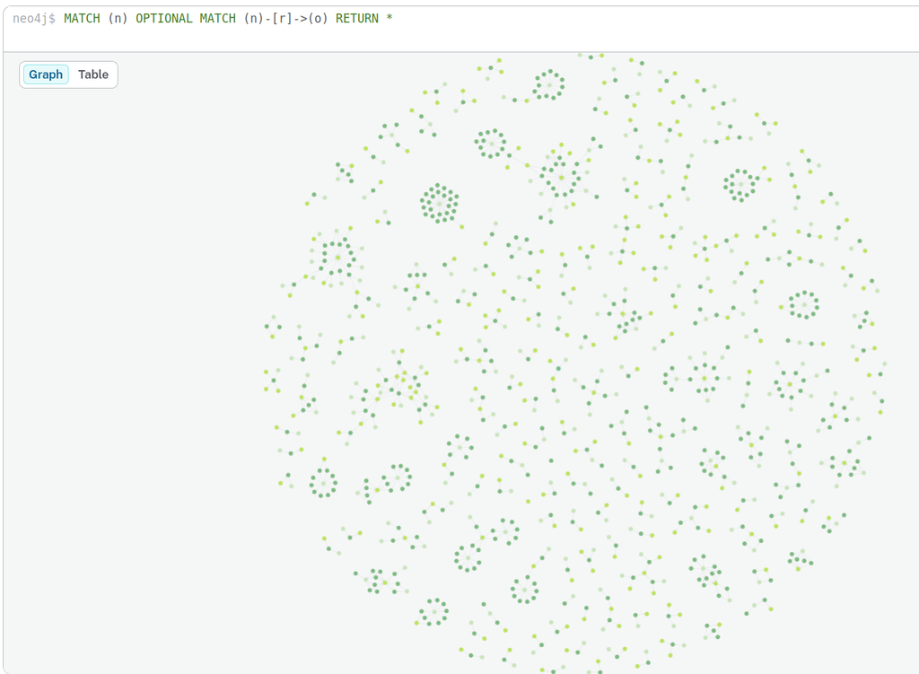

Figure 9: The full graph after importing the larger dataset, with many more connected nodes than the small sample.

# References

1. Misquitta, L. and Willemsen, C. (2025) *Neo4j: The Definitive Guide: Hands-On Recipes for Production Ready Graph Implementations*. O’Reilly Media.
2. Bratanic, T. and Hane, O., 2025. Essential GraphRAG: Knowledge Graph-Enhanced RAG. Simon and Schuster.